# R package MittagLeffleR: Using the Mittag-Leffler distributions in R

Peter Straka

2017-06-26

Ricky Gill and I have created the R package MittagLeffleR, documented at strakaps.github.io/MittagLeffleR/. It is available on [CRAN](https://cran.r-project.org/web/packages/MittagLeffleR/index.html) (and the latest development version on [GitHub](https://github.com/strakaps/MittagLeffleR)). MittagLeffleR calculates both Mittag-Leffler distributions; i.e. probability density, cumulative distribution function, quantile function and fast random variate generation. It was made possible by the [Laplace inversion algorithm](https://au.mathworks.com/matlabcentral/fileexchange/48154-the-mittag-leffler-function) for the Mittag-Leffler function by [Roberto Garrappa](https://twitter.com/rgarrappa). Install it via

```r
install.packages("MittagLeffleR")
```

## The Two Mittag-Leffler distributions

Various journal articles (including my own) write about “the” Mittag-Leffler distribution, but actually there are [*two* such families of distributions](https://en.wikipedia.org/wiki/Mittag-Leffler_distribution). Both have a shape parameter (`tail`) taken from the interval $(0,1]$, but the first distribution is *very heavy-tailed* with infinite mean if `tail` $\in (0,1)$ (it is equal to the exponential distribution if `tail` $=1$) whereas the second distribution is light-tailed (has finite moments of all orders). The boolean variable `second.type` switches between these two distributions.

## Examples

### First type = waiting times between events

The first type Mittag-Leffler distribution commonly occurs for the **inter-arrival times between events in complex systems** (e.g. earthquakes, see future post). Suppose that for an event to happen, several “tries” are needed, and that each try has a duration. The number $N$ of tries until a success is geometrically distributed, and the *sum* of $N$ durations is well approximated by a Mittag-Leffler (type I) distribution (this is the [geometric stable](https://github.com/strakaps/MittagLeffleR) property).

As an example, we simulate `n=100` Mittag-Leffler (type I) random variables, and estimate their tail and scale parameters via maximum likelihood:

```r
library(MittagLeffleR)
y = rml(n = 100, tail = 0.9, scale = 2)
mlml <- function(X) {
  log_l <- function(theta) {
    #transform parameters so can do optimization unconstrained
    theta[1] <- 1/(1+exp(-theta[1]))
    theta[2] <- exp(theta[2])
    -sum(log(dml(X,theta[1],theta[2])))
  }
  ml_theta <- stats::optim(c(0.5,0.5), fn=log_l)$par
  #transform back
  ml_a <- 1/(1 + exp(-ml_theta[1]))
  ml_d <- exp(ml_theta[2])
  return(list("tail" = ml_a, "scale" = ml_d))
}
mlml(y)
```

```
## $tail
## [1] 0.9415339
##
## $scale
## [1] 2.271046
```

### Second type = number of events

The second type Mittag-Leffler distribution typically occurs for the random **number of events in complex systems**. For instance, assume a random walk with heavy-tailed waiting times; this has become a widely adopted model for [anomalous diffusion](https://en.wikipedia.org/wiki/Anomalous_diffusion). For late times, its number of steps [can be well approximated by a Mittag-Leffler (type II) distribution](https://doi.org/10.1017/S002190020002043X).

The time-change of a random walk by the random number of steps is called *subordination*; the random number of steps is approximated by the [inverse stable subordinator](https://stt.msu.edu/users/mcubed/hittingTime.pdf). Below we calculate the probability density of a random walker with step size `dx=0.01`:

- the number of steps up to time $t$ is stored in the vector $h$
- the matrix $N$ stores the probability distribution at the lattice sites at consecutive times
- the “subordination” happens in the matrix product `N %*% h`.

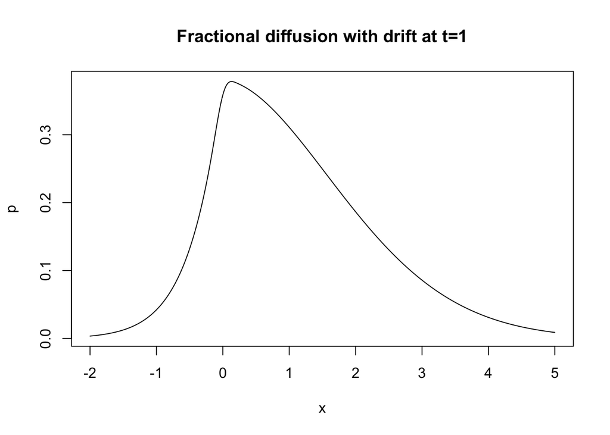

```r
library(MittagLeffleR)
tail <- 0.65
dx <- 0.01
x <- seq(-2,5,dx)
umax <- qml(p=0.99, tail=tail, scale=1, second.type=TRUE)
u <- seq(0.01,umax,dx)
h <- dml(x=u, tail=tail, scale=1, second.type=TRUE)
N <- outer(x,u,function(x,u){dnorm(x=x, mean=u, sd=sqrt(u))})
p <- N %*% h * dx
plot(x,p, type='l', main="Fractional diffusion with drift at t=1")
```

## Bugs and Issues

Should you run into any bugs or issues, please [let us know](https://github.com/strakaps/MittagLeffleR/issues). Thanks!